# Mouse Development ENCODE RNA-seq Alternative Splicing Exploration

# Intro

[ENCODE released](https://www.encodeproject.org/mouse-development-matrix/?type=Experiment&status=released&related_series.@type=OrganismDevelopmentSeries&replicates.library.biosample.organism.scientific_name=Mus+musculus) a nice dataset of different genomics data at different stages of development in different tissues.

I took their RNA-seq data and analysed it with vast-tools to make a plot for the supplementary figure 1 of our [paper](https://doi.org/10.1101/2023.04.30.538846).

While analysing the data I ended up making a function that queries the vast-tools output tables and a nice plotting function. Here I show how to use them.

# Pax6 exon 6 example

## Import pre-precessed data

These vignette showcase how to analyse one single alternative splicing (AS) event at the time. This is not a high-level data exploration. The function `get_mouse_tissue_devel_tbl()` in this package let’s you import into R all the metadata, gene expression levels, and PSI of an AS event. All you need is a valid [mouse ensembl gene id](http://www.ensembl.org/Mus_musculus/Info/Index) and an AS event vast-tools id, that you can find in [VastDB](https://vastdb.crg.eu/wiki/Main_Page).

For example if you want to explore *Pax6* exon 6 PSI across different tissues and embryonic stages, simply run

```r
Pax6 <- get_mouse_tissue_devel_tbl(ensembl_gene_id = "ENSMUSG00000027168",
                                   vst_id = "MmuEX0033804")
```

where [`ENSMUSG00000027168`](http://www.ensembl.org/Mus_musculus/Gene/Summary?db=core;g=ENSMUSG00000027168;r=2:105499245-105527709) is the ensembl gene id of Pax6 and [`MmuEX0033804`](https://vastdb.crg.eu/event/MmuEX0033804@mm10) is the mouse AS id.

The pre-processed data is stored on the CRG cluter at `/users/mirimia/narecco/projects/07_Suz12AS/data/INCLUSION_tbl/Mouse_Development/vast_tools/vast_out`. You should be able to access it easily, but if you get an error that might be related to access rights, please [open a GitHub issue](https://github.com/Ni-Ar/niar/issues/new) or write me an email. Of course this wrapper works only if you have access to the CRG cluster and works very well using the [CRG RStudio Server IDE](https://rstudio42.linux.crg.es/). If this was a proper `R` package the pre-processed data would be attached to the package, but for sack of convenience I wanted to keep the `niar` package lightweight.

## Plot the data

To visually represent the data like in the Arecco, Mocavini et al. publication simply run:

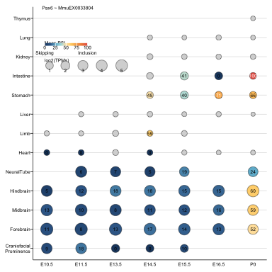

```r
plot_mouse_tissue_devel(data_tbl = Pax6, legend = "inside", colour_bar = 'BlueRed')
```

The developmental stages are on the X-axis, and the different tissues are on the Y-axis. The dots size represent the expression levels of the gene specified with `ensembl_gene_id` when querying the data. The dots colour represent the PSI value of the exon specified with `vst_id` before. If you don’t like this colour palette you can use `colour_bar = 'viridis'` as an alternative. Also the legend position can adjusted with `legend = "outside"`.

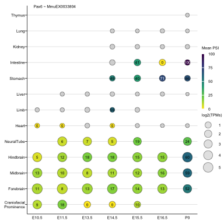

```r
plot_mouse_tissue_devel(data_tbl = Pax6, legend = "outside", colour_bar = 'viridis')
```

There are other additional features like limiting the PSI range with `PSI_limits = c(0, 100)` or deciding PSI threshold to show PSI numbers with black text rather than white (PSI of 100 in black is hard to read on a dark purple background).

Lastly you can save the plot on the fly with `save_plot = TRUE` and specifying the location where to save with `out_plot_dir = /path/to/file` and the plot name with the `plot_name` parameter. These last parameters have good defaults options so not really required in my option. To know more run: `?get_mouse_tissue_devel_tbl()`.

# PTBP1 & PTBP2 example

These 2 function can also be used to plot an exon PSI and the expression of another gene. To display this I like to use the Ptbp1/2 NMD-dependent cross-regulation. (See PMID: 26293963 and 17606642 for details).

- `ENSMUSG00000006498` = *Ptbp1*; `MmuEX0037628` = *Ptbp1* exon 9
- `ENSMUSG00000028134` = *Ptbp2*; `MmuEX0037640` = *Ptbp2* exon 11

Briefly, *Ptbp1* splicing factor repress the inclusion *Ptbp2* exon 11 triggering NMD and resulting in lower level of PTBP2 in non-neuronal cells.

Here I plot the expression of *Ptbp1* and *Ptbp2* exon 11 PSI.

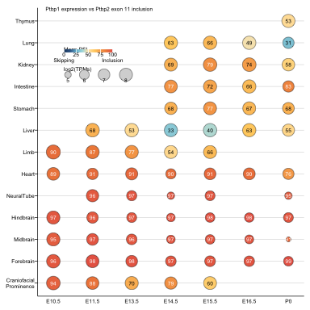

```r
get_mouse_tissue_devel_tbl(ensembl_gene_id = "ENSMUSG00000006498",
                           vst_id = "MmuEX0037640") |>
  plot_mouse_tissue_devel(legend = "inside", colour_bar = 'BlueRed',
                          title = "Ptbp1 expression vs Ptbp2 exon 11 inclusion",
                          blck_wht_PSI_col_thshld = 75)
```

As one can see the tissues and developmental stages where the exon is more lowly included are those where *Ptbp1* are more included.

Here instead I show how the gene expression (expressed in log2 TPMs) of *Ptbp2* is higher in the tissues where the exon 11 inclusion levels are higher.

[figure not shown]

```r
get_mouse_tissue_devel_tbl(ensembl_gene_id = "ENSMUSG00000028134",
                           vst_id = "MmuEX0037640") |>
  plot_mouse_tissue_devel(legend = "inside", colour_bar = 'BlueRed',
                          title = "Ptbp2 expression vs Ptbp2 exon 11 inclusion",
                          blck_wht_PSI_col_thshld = 75)
```

Note how the data retrieving function output is piped on the fly to the plotting function input with `|>`. If you don’t have R 4.1+ you can use magrittr `%>%` operator.